# Response of andean plant communities to increases in temperature and droughts

Alejandro Jaramillo Urán

2025-04-02

# 1 Content

This page includes the code used to calculate the **community temperature score (CTS)** (the average of the thermal optima of species in a plot) using ~18 years iof tree plot data. The CTS is an index and its positive change over time is referred to as thermophilization. A positive change indicates an increase in the relative abundance of lowland species.

The 24 plots are located in north-east Antioquia. There are two different tables (p2 and p3) depending on the project under which the plots were constructed

# 2 Species

Species occurring in the plots

```r
p2 <- read.csv("datos_base/corregidas/p2_arboles.csv")
p2_sp <- unique(p2$especies)
head(p2_sp)
```

```
## [1] "Aiouea montana"          "Aniba muca"
## [3] "Pseudolmedia laevigata"  "Miconia trinervia"
## [5] "Neea divaricata"         "Aspidosperma spruceanum"
```

```r
p3 <- read.csv("datos_base/corregidas/p3_arboles.csv")
p3_sp <- unique(p3$especies)
head(p3_sp)
```

```
## [1] "Clusia pallida"        "Hippotis mollis"       "Hasseltia floribunda"
## [4] "Casearia arborea"      "Turpinia occidentalis" "Tapirira guianensis"
```

**Code** for getting sp occurrences from gbif using R on my **GitHub**: getting_sp_ocurrences

# 3 Thermal optima of each species

First, filter the species occurrences. Then, calculate the species’ thermal optima as the mean of the occurrences mean annual temperature obtained from CHELSA.

```r
library(spThin)
library(dplyr)
sp_occurrences <- read.csv2("ocurrencias_info_climatica/ocurrencia_spp/ocurrencias_FINAL.csv", sep = ",")

#number of occurrences per species
n_ocurrences <- sp_occurrences %>% group_by(species) %>%
  summarise(n_occurrences = n())

head(n_ocurrences)
```

```
## # A tibble: 6 × 2
##   species                n_occurrences
##   <chr>                          <int>
## 1 Acalypha diversifolia           1143
## 2 Acalypha macrostachya            948
## 3 Aegiphila integrifolia           359
## 4 Aegiphila truncata               123
## 5 Aiouea lehmannii                   9
## 6 Aiouea montana                   414
```

```r
#Function for filtering occurrences
thin_species <- function(data) {
  thin_loc <- thin(loc.data = data,
                    lat.col = "y", long.col = "x",
                    spec.col = "species",
                   #distance in kilometers the records to be separate by
                    thin.par = 1,
                   #repetitions
                    reps = 10,
                    locs.thinned.list.return = TRUE,
                    write.files = TRUE,
                   #two filer per species
                    max.files = 2,
                    out.dir = "directory/",
                    out.base = paste0("thinned_", unique(data$species)),
                    write.log.file = TRUE,
                    log.file = paste0("thinned_", unique(data$species), "_log_file.txt"))
  return(thin_loc)
}

thin_results <- tapply(sp_occurrences, sp_occurrences$species, thin_species)

#Getting climatic (Bio1) information
library(raster)
library(terra)
bio1_chelsa <- terra::rast("./capas/clima/CHELSA_bio1_1981-2010_V.2.1.tif")

#Function:
climatic_info <- function(spp, bio1_chelsa) {
  spp$x <- as.numeric(spp$x)
  spp$y <- as.numeric(spp$y)


  spp_vect <- terra::vect(spp, geom = c("x", "y"), crs = crs(bio1_chelsa))

  spp$bio1_chelsa <- terra::extract(bio1_chelsa, spp_vect)[,2]

  csv_file <- paste0("directory/", as.character(spp[1, "species"]), ".csv")

  write.csv(spp, csv_file, row.names = FALSE)
}

list_thermal_optima <- lapply(species_occurrences_list, climatic_info, bio1_chelsa)
```

# 4 Community Temperature Score (CTS)

For each plot in each census, the CTS is calculated. There are two different categories: Adults: trees with a DBH > 10 cm; Juveniles: trees with a 1cm >= DBH <= 10cm

**CTS:** the average of the thermal optima of species in a plot weighted by the species abundance in that census.

```r
#EXAMPLE CODE WITH ONLY P2 PLOTS
#There are a different data frame for each census: 8 total
#A list with all the data frames:
files_p2 <- list.files("dfs/census/", pattern = ".csv", full.names = T)
df_p2 <- lapply(files_p2, FUN = read.csv)


#census years
years_p2 <- c(2004, 2006, 2008, 2010, 2013, 2016, 2019, 2022)

#Load a data frame with species thermal optima
thermal_optima <- read.csv("thermal_optima.csv")

#Function for cts calculation
cts <- function (files_list, thermal_optima, years){
  results <- list()
  for (i in 1:length(files_list)){
    df <- files_list[[i]]
    df_nombre <- paste0("cts_p2_", years[i], ".csv")

    #climatic information
    df <- merge(df, thermal_optima,
                by.x = "species",
                by.y = "species_lim",
                all.x = T)

    # Group by plot, category and species to calculate abundance
    df <- df %>% group_by(plot, category, species) %>%
      mutate(num_ind = n()) %>%
      distinct(plot, category, species) %>%
      ungroup()

    #CTS calculation
    df <- df %>%
      group_by(plot, category) %>%
      summarise(
        Bio1_chelsa_weighted = sum(Bio1_chelsa * num_ind, na.rm = TRUE) / sum(num_ind, na.rm = TRUE))

    write.csv(df, paste0("directory/", df_nombre), row.names = FALSE)

    # save result
    results[[i]] <- df
  }
  return(results)
}

cts_results_p2 <- cts(df_p2, thermal_optima, years_p2)
```

# 5 Temperature

Source: https://mapas-212104.projects.earthengine.app/view/anlisis-global-de-temperatura-y-precipitacin

Era5 has information on minimum, mean and maximum temperature.

Climatic satellite information can also be accessed via Google Earth Engine. Here is an [example using python](https://github.com/AlejandroJaramilloUran/climate_data) on my **GitHub** profile.

## 5.1 Temperature trend

[figure not shown]

```r
library(tidyr)
library(ggplot2)
era5 <- read.csv("era5_daily.csv")

#Average temperature between plots
era5 <- era5 %>%
  #group by each day
  group_by(day) %>%
  mutate(tmax_mean = mean(tmax),
         tmean_mean = mean(tmean),
         tmin_mean = mean(tmin)) %>%
  dplyr::select(day, tmax_mean, tmean_mean, tmin_mean) %>%
  distinct()

#Convert to long format
era5_long <- era5 %>%
  pivot_longer(
    cols = c(tmax_mean, tmean_mean, tmin_mean),
    names_to = "variable",
    values_to = "temperature"
  )

# plot using ggplot
ggplot(era5_long, aes(
  x = as.Date(day),
  y = temperature,
  color = variable
)) +
  geom_line(size = 1) +
  geom_smooth(aes(group = variable),
              method = "lm",
              se = FALSE,
              color = "black",
              linetype = "dashed",
              size = 1) +
  scale_color_manual(
    values = c("tmax_mean"  = "#8F1A00",
               "tmean_mean" = "#FBC246",
               "tmin_mean"  = "#08519c"),
    labels = c("tmax_mean"  = "Tmáx",
               "tmean_mean" = "mean",
               "tmin_mean"  = "Tmin")
  ) +
  labs(
    x = "Fecha",
    y = "Temperatura (°C)",
    color = "",
    title = ""
  ) +
  theme_minimal() +
  theme(
    aspect.ratio = 1.2,
    axis.text.x  = element_text(size = 14, hjust = 0.5),
    axis.text.y  = element_text(size = 14),
    axis.title   = element_text(size = 16),
    plot.title   = element_text(size = 18, face = "bold", hjust = 0.5),
    legend.position = c(0.3, 0.95),
    legend.direction= "horizontal",
    panel.border = element_rect(color = "black", fill = NA),
    panel.grid.major = element_blank(),
    panel.grid.minor = element_blank()
  )
```

## 5.2 Temperature for each plot

Calculation of average max, mean and min temperature one year prior to each census on each plot

```r
library(lubridate)

# dates on which the censuses were made in each plot
dates <- read.csv("datos_base/fechas_censos.csv")

#fecha_inicio: date on which the census was made
#fecha_fin: day before the next census
head(dates)
```

```
##   parcela_id fecha fecha_inicio  fecha_fin
## 1   Porce2_1  2006   2004-06-15 2006-07-14
## 2   Porce2_2  2006   2004-06-15 2006-07-14
## 3   Porce2_3  2006   2004-06-15 2006-07-14
## 4   Porce2_4  2006   2004-06-15 2006-07-14
## 5   Porce2_5  2006   2004-06-15 2006-07-14
## 6   Porce2_6  2006   2004-06-15 2006-07-14
```

```r
# era5 daily temperature for the plots:
era5 <- read.csv("era5_daily.csv")

#Year extraction from the dates using lubridate
dates <- dates %>%
  mutate(year_inicio = year(fecha_inicio))

dates <- dates %>%
  mutate (year_fin = year(fecha_fin))

#creation of new columns
dates$tmin_anio <- NA
dates$tmean_anio <- NA
dates$tmax_anio <- NA

#Loop to calculate the average temperatures one year prior to each census on each plot

for (i in 1:nrow(dates)) {

  plot <- dates$parcela_id[i]

  # dates of interest
  inicio <- dates$fecha_inicio[i] - years (1)
  fin <- dates$fecha_inicio[i]

  tem_anio <- era5 %>%

    #use the current plot
    filter(parcela_id == plot,

           #filter for dates
           fecha_formato >= inicio,
           fecha_formato <= fin) %>%

    #averages
    summarise(tmin_year = mean(tmin),
              tmean_year = mean (tmean),
              tmax_year = mean (tmax))

  dates$tmin_anio[i] <- tem_anio$tmin_year
  dates$tmean_anio[i] <- tem_anio$tmean_year
  dates$tmax_anio[i] <- tem_anio$tmax_year
}
```

# 6 Drought

Severe and extreme droughts occurring between censuses for each plot using SPEI on a 6-month scale.

Source: https://essd.copernicus.org/articles/15/5449/2023/

The SPEI files are on a global scale. Here is an example of how to [filter and proccess them using R](https://github.com/AlejandroJaramilloUran/climate_data) on my **GitHub** profile.

Calculation of number of severe and extreme drought events occurring in each interval for each plot

```r
# dates on which the censuses were made in each plot
dates <- read.csv("datos_base/fechas_censos.csv")

# load the time series with the drought values for every month from 2004 - 2022 for each plot
spei_06<- read.csv("spei06.csv")

# Calculation of drought events

drought_results <- dates %>%

  # A join using the column parcela_id
  left_join(spei_06, by = "parcela_id") %>%

  # Filter using dates
  filter(FECHA_SPEI >= fecha_inicio & FECHA_SPEI <= fecha_fin) %>%
  group_by(parcela_id, fecha, fecha_inicio, fecha_fin) %>%
  summarise(
    severe_drought   = sum(spei <= -1.43 & spei > -1.83, na.rm = TRUE),
    extreme_drought  = sum(spei <= -1.83, na.rm = TRUE),
    .groups = "drop"
  )

# Finally, we calculate severe + extreme drought
drought_results$drought_events <- drought_results$severe_drought + drought_results$extreme_drought
```

# 7 Statistical model

In order to see the relationship between CTS, temperature and drought frequency, a linear mixed model was run.

## 7.1 Data

This is how the table looks:

```r
cts <- read.csv("cts.csv")
head(cts)
```

```
##   parcela_id date category cts_bio1 elevation                  vegetation_cover
## 1   Porce2_1 2004   Adulto 23.56588      1010 Bosque denso alto de tierra firme
## 2   Porce2_1 2004  Juvenil 23.41901      1010 Bosque denso alto de tierra firme
## 3   Porce2_2 2004   Adulto 23.51550      1020 Bosque denso alto de tierra firme
## 4   Porce2_2 2004  Juvenil 23.19408      1020 Bosque denso alto de tierra firme
## 5   Porce2_3 2004   Adulto 20.24454       925 Bosque denso alto de tierra firme
## 6   Porce2_3 2004  Juvenil 20.31701       925 Bosque denso alto de tierra firme
##   temperature_max drought
## 1        24.95546       0
## 2        24.95546       0
## 3        24.95546       0
## 4        24.95546       0
## 5        24.95546       0
## 6        24.95546       0
```

## 7.2 Exploration

Distribution of CTS within categories or coverages

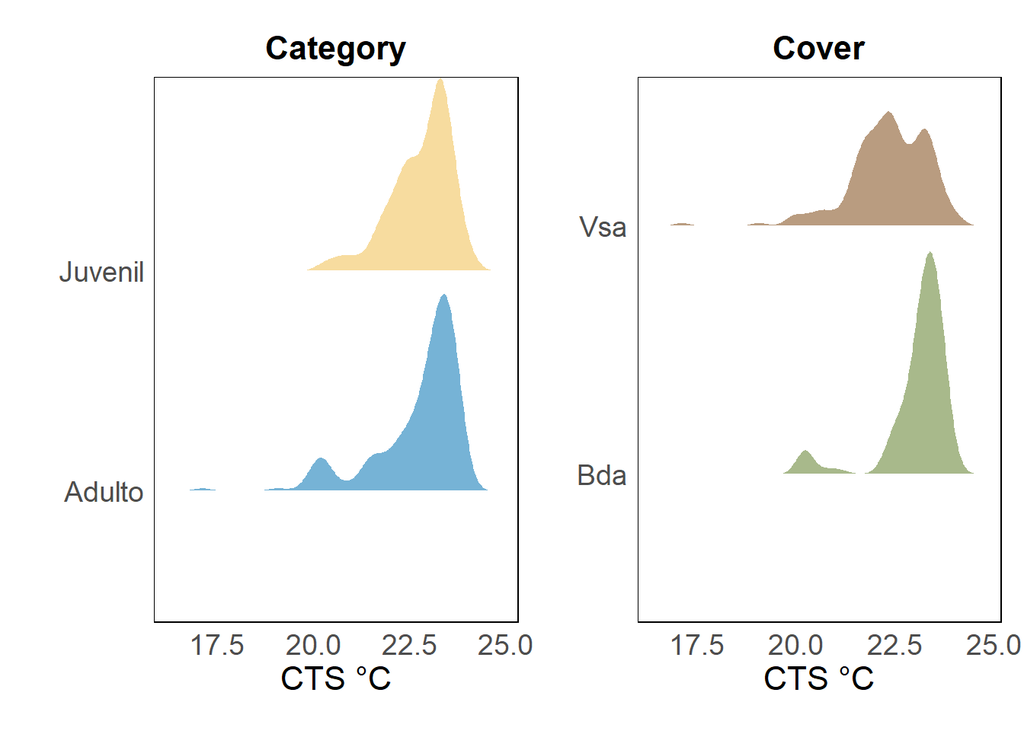

```r
library(ggridges)
library(ggplot2)

cat <- ggplot(cts, aes(
  x = cts_bio1,
  y = category,
  fill = category
)) +
  geom_density_ridges(
    alpha = 0.6,
    color = "white",
    scale = 0.9
  ) +
  scale_fill_manual(values = c("Adulto" = "#1a80bb", "Juvenil" = "#f2c45f")) +
  labs(
    x = "CTS °C",
    y = "",
    fill = "",
    title = "Category"
  ) +
  theme_minimal() +
  theme(aspect.ratio = 1.5,
    axis.text.x    = element_text(size = 14),
    axis.text.y    = element_text(size = 14),
    axis.title     = element_text(size = 16, face = "plain"),
    legend.position = "none",
    panel.grid     = element_blank(),
    plot.title     = element_text(size = 16, face = "bold", hjust = 0.5),
    panel.border   = element_rect(color = "black", fill = NA)
  )

cob <-(ggplot(cts, aes(
  x = cts_bio1,
  y = vegetation_cover,
  fill = vegetation_cover
)) +
  geom_density_ridges(
    alpha = 0.6,
    color = "white",
    scale = 0.9
  ) +
  scale_fill_manual(values = c("Bosque denso alto de tierra firme" = "#6E8B3D",
                               "Vegetacion secundaria alta" = "#8B5A2B")) +
    scale_y_discrete(labels = c("Bosque denso alto de tierra firme" = "Bda",
                                "Vegetacion secundaria alta" = "Vsa")) +
  labs(
    x = "CTS °C",
    y = "",
    fill = "",
    title = "Cover"
  ) +
  theme_minimal() +
  theme(aspect.ratio = 1.5,
        axis.text.x    = element_text(size = 14),
        axis.text.y    = element_text(size = 14),
        axis.title     = element_text(size = 16, face = "plain"),
        legend.position = "none",
        panel.grid     = element_blank(),
        plot.title     = element_text(size = 16, face = "bold", hjust = 0.5),
        panel.border   = element_rect(color = "black", fill = NA)
  ))

library(patchwork)
cat + cob
```

## 7.3 Linear mixed model

```r
# standardization of explanatory variables
vbles <- c("drought", "temperature_max")
cts_sd <- data.frame(cts, scale(cts[,vbles]))

cts_sd <- cts_sd %>%
  mutate(across(c(category, parcela_id, vegetation_cover), as.factor))

#Model using parcela_id as a random factor and temperature, drought, category and cover as fixed factors
library(lme4)
library(lmerTest)

model <- lmer(cts_bio1 ~ temperature_max.1 + drought.1 + vegetation_cover + category +
                         (1|parcela_id),
                       data = cts_sd)
```

```r
#Extraction of the model coefficients
coeffs <- summary(model)$coefficients
coeffs_df <- data.frame(
  variable = rownames(coeffs),
  estimado = coeffs[, "Estimate"],
  se       = coeffs[, "Std. Error"],
  p.value  = coeffs[, "Pr(>|t|)"]
)

#Estimation of confidence intervals
i.c <- confint(model, method = "boot", nsim = 1000)
i.c.fixed <- i.c[rownames(i.c) %in% coeffs_df$variable, ]
coeffs_df$ci_low  <- i.c.fixed[, 1]
coeffs_df$ci_high <- i.c.fixed[, 2]

#Delete the intercept
coeffs_df <- subset(coeffs_df, variable != "(Intercept)")
```

```r
#Coefficients:
coeffs_cts <- read.csv("coeffs_cts.csv")
coeffs_cts
```

```
##   variable    estimate         se      p.value      ci_low    ci_high        sd
## 1     Tmax  0.08159679 0.03169256 0.0105310133  0.01829747  0.1445301 0.7473358
## 2 droughts  0.11514696 0.02882630 0.0000825069  0.05744107  0.1710710 2.8150157
## 3      VSA -0.75413423 0.31693212 0.0263495501 -1.37744358 -0.1300199        NA
## 4  Juvenil  0.09754478 0.05662537 0.0860387683 -0.02077926  0.2139077        NA
```

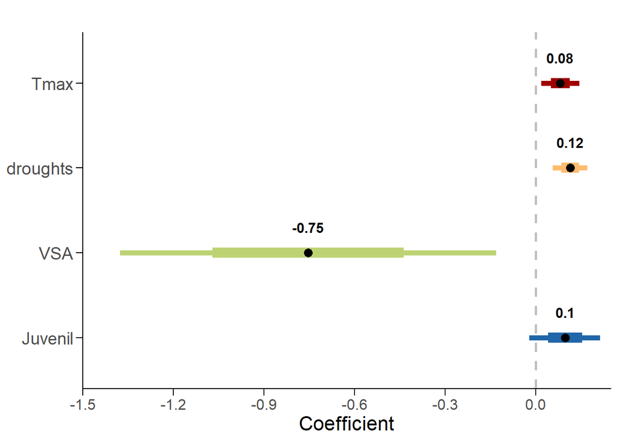

```r
#Coefficients plot showing cofidence intervals and standard errors
plot_model <- ggplot(coeffs_cts, aes(x = estimate, y = variable)) +
  geom_errorbarh(aes(xmin = ci_low, xmax = ci_high, color = variable), height = 0, size = 2) +
  geom_errorbarh(aes(xmin = estimate - se, xmax = estimate + se, color = variable), height = 0, size = 4) +
  geom_point(color = "black", size = 3) +
  geom_text(aes(label = round(estimate, 2)),
            nudge_y = 0.3,
            size = 4,
            color = "black",
            fontface = "bold") +
  geom_vline(xintercept = 0, linetype = "dashed", color = "gray50", size = 1, alpha = 0.5) +
  scale_color_manual(values = c("Tmax" = "#a00000",
                                "droughts" = "#ffbb6f",
                                "VSA" = "#bdd373",
                                "Juvenil" = "#2066a8")) +
  scale_y_discrete(limits = rev(c("Tmax", "droughts", "VSA", "Juvenil"))) +
  scale_x_continuous(limits = c(-1.5, 0.25),
                     breaks = seq(-1.5, 0.25, by = 0.3),
                     expand = c(0, 0)) +
  theme_minimal() +
  labs(x = "Coefficient", y = NULL, title = "") +
  theme(
    panel.grid         = element_blank(),
    panel.border       = element_blank(),
    axis.line          = element_line(color = "black"),
    axis.ticks         = element_line(color = "black"),
    axis.ticks.length  = unit(0.2, "cm"),
    axis.line.x.top    = element_blank(),
    axis.line.y.right  = element_blank(),
    axis.text.x        = element_text(size = 12, vjust = 1, hjust = 0.5),
    axis.text.y        = element_text(size = 14),
    axis.title         = element_text(size = 16, face = "plain"),
    legend.position    = "none",
    strip.text         = element_text(size = 18, face = "bold"),
    plot.title         = element_text(size = 16, face = "bold", hjust = 0.5)
  )

plot_model
```

# 8 References

Gebrechorkos, S. H., Peng, J., Dyer, E., Miralles, D. G., Vicente-Serrano, S. M., Funk, C., Beck, H. E., Asfaw, D. T., Singer, M. B., & Dadson, S. J. (2023). Global high-resolution drought indices for 1981–2022. *Earth System Science Data*, *15*(12), 5449-5466. https://doi.org/10.5194/essd-15-5449-2023